# NYPD Shootings

2024-04-08

[figure not shown]

```r
  url <- "https://data.cityofnewyork.us/api/views/833y-fsy8/rows.csv?accessType=DOWNLOAD"

  nypd_data_full <- read_csv(url)

  nypd_data <- nypd_data_full %>% select(-c(LOC_OF_OCCUR_DESC, LOC_CLASSFCTN_DESC, LOCATION_DESC, X_COORD_CD, Y_COORD_CD, Latitude, Longitude, Lon_Lat)) %>% mutate(OCCUR_DATE = mdy(OCCUR_DATE))

  nypd_shootings_dates <- nypd_data %>%
                          group_by(OCCUR_DATE) %>%
                          mutate(occurences = n(), murders = sum(STATISTICAL_MURDER_FLAG)) %>%
                          select(OCCUR_DATE, occurences, murders)


  # creates shootings yearly df
  nypd_shootings_yearly <- nypd_shootings_dates %>%
    mutate(year = year(OCCUR_DATE)) %>%
    group_by(year) %>%
    summarize(occurences = sum(occurences), murders = sum(murders)) %>%
    select(year, occurences, murders)

  # creates plot for shooting occurences and murders year-over-year
  nypd_shootings_yearly %>% ggplot(aes(x = year, y = occurences)) +
    geom_line(aes(color="occurences")) +
    geom_line(aes(y=murders, color="murders")) +
    theme(legend.position="bottom", axis.text.x=element_text(angle=90)) +
    labs(title = "NYPD Shooting Occurences and murders by year", y = NULL)
```

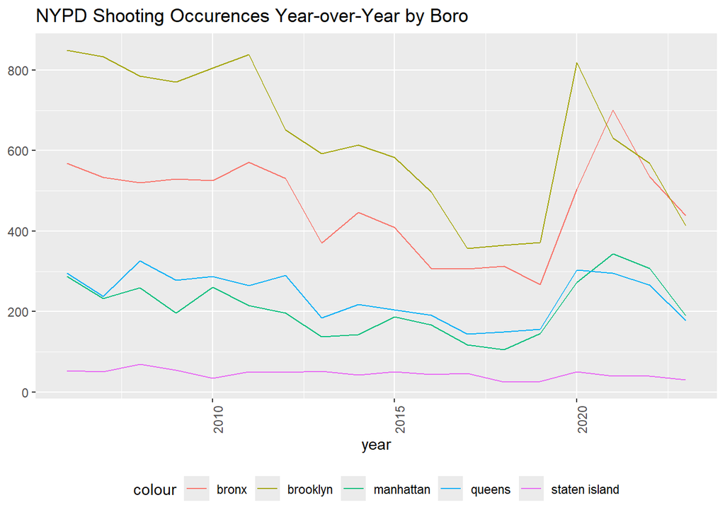

```r
  # creates shooting occurences and murders by year and boro
  nypd_shootings_yearly_by_boro <- nypd_data %>%
    mutate(year = year(OCCUR_DATE), boro = BORO) %>%
    group_by(year, boro) %>%
    summarize(occurences = n(), murders = sum(STATISTICAL_MURDER_FLAG)) %>%
    select(year, boro, occurences, murders)

  # creates a separate df for each boro's year-to-year shooting occurences and murders
  bronx_yearly = nypd_shootings_yearly_by_boro[which(nypd_shootings_yearly_by_boro$boro == "BRONX"), ]
  brooklyn_yearly = nypd_shootings_yearly_by_boro[which(nypd_shootings_yearly_by_boro$boro == "BROOKLYN"), ]
  manhattan_yearly = nypd_shootings_yearly_by_boro[which(nypd_shootings_yearly_by_boro$boro == "MANHATTAN"), ]
  queens_yearly = nypd_shootings_yearly_by_boro[which(nypd_shootings_yearly_by_boro$boro == "QUEENS"), ]
  si_yearly = nypd_shootings_yearly_by_boro[which(nypd_shootings_yearly_by_boro$boro == "STATEN ISLAND"), ]


  # creates plot for shooting occurences year-over-year by boro
  ggplot() +
  geom_line(data = bronx_yearly, aes(x = year, y = occurences, color="bronx")) +
  geom_line(data = brooklyn_yearly, aes(x = year, y = occurences, color="brooklyn")) +
  geom_line(data = manhattan_yearly, aes(x = year, y = occurences, color="manhattan")) +
  geom_line(data = queens_yearly, aes(x = year, y = occurences, color="queens")) +
  geom_line(data = si_yearly, aes(x = year, y = occurences, color="staten island")) +
  theme(legend.position="bottom", axis.text.x=element_text(angle=90)) +
  labs(title = "NYPD Shooting Occurences Year-over-Year by Boro", y = NULL)
```

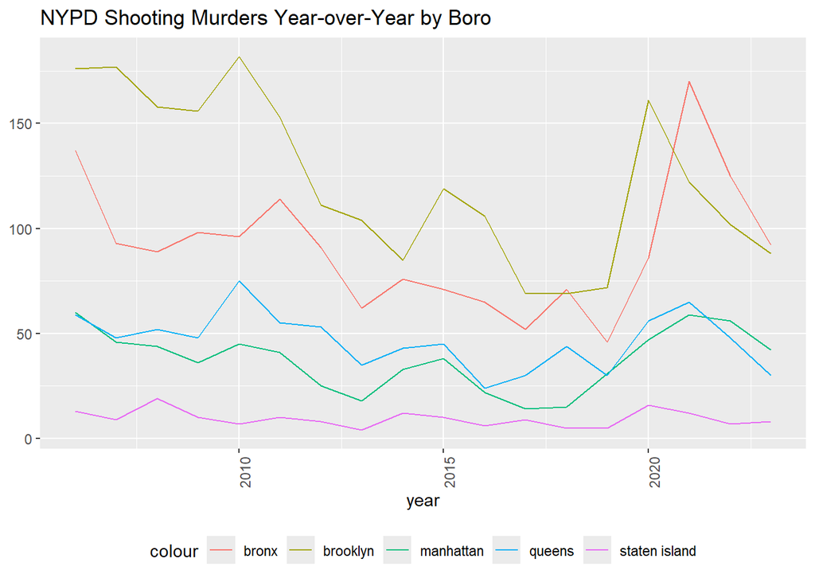

```r
  # creates plot for murders year-over-year by boro
  ggplot() +
  geom_line(data = bronx_yearly, aes(x = year, y = murders, color="bronx")) +
  geom_line(data = brooklyn_yearly, aes(x = year, y = murders, color="brooklyn")) +
  geom_line(data = manhattan_yearly, aes(x = year, y = murders, color="manhattan")) +
  geom_line(data = queens_yearly, aes(x = year, y = murders, color="queens")) +
  geom_line(data = si_yearly, aes(x = year, y = murders, color="staten island")) +
  theme(legend.position="bottom", axis.text.x=element_text(angle=90)) +
  labs(title = "NYPD Shooting Murders Year-over-Year by Boro", y = NULL)
```

```r
  # creates a df for shootings year-over-year by boro (copy of a couple lines above?)
  nypd_shootings_yearly_by_boro <- nypd_data %>%
    mutate(year = year(OCCUR_DATE), boro = BORO) %>%
    group_by(year, boro) %>%
    summarize(occurences = n(), murders = sum(STATISTICAL_MURDER_FLAG)) %>%
    select(year, boro, occurences, murders)
```

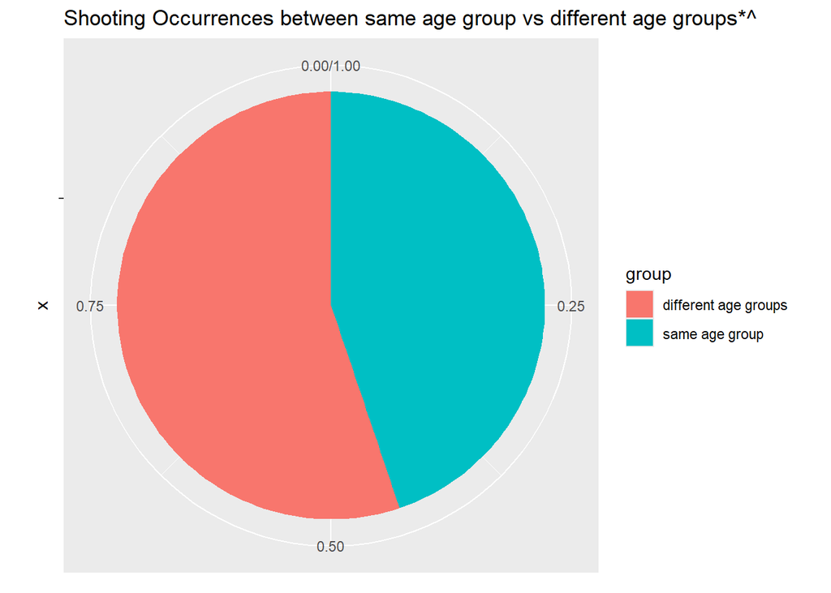

```r
  # finding
  age_match <- length(which(nypd_data$VIC_AGE_GROUP == nypd_data$PERP_AGE_GROUP & !(nypd_data$VIC_AGE_GROUP == "UNKNOWN" | nypd_data$PERP_AGE_GROUP == "UNKNOWN" | nypd_data$VIC_AGE_GROUP == "1022" | nypd_data$PERP_AGE_GROUP == "1022")))
  age_no_match <- length(which(nypd_data$VIC_AGE_GROUP != nypd_data$PERP_AGE_GROUP & !(nypd_data$VIC_AGE_GROUP == "UNKNOWN" | nypd_data$PERP_AGE_GROUP == "UNKNOWN" | nypd_data$VIC_AGE_GROUP == "1022" | nypd_data$PERP_AGE_GROUP == "1022")))
  # unique(nypd_data$VIC_AGE_GROUP)

  # creates df with % of shooting occurrences where victim and perp are the same age group
  # vs different age groups
  age_match_percent = age_match/(age_match + age_no_match)
  age_no_match_percent = age_no_match/(age_match + age_no_match)
  age_percent_df <- data.frame(
                    group = c("same age group", "different age groups"),
                    value = c(age_match_percent, age_no_match_percent))

  # pie chart of occurences where victim and perp are in the same age group vs different age groups
  ggplot(age_percent_df, aes(x="", y=value, fill=group)) +
  geom_bar(stat="identity", width=1) +
  coord_polar("y", start=0) +
  labs(title = "Shooting Occurrences between same age group vs different age groups*^", y = NULL)
```

```r
  # message displaying the percentage breakdowns of the pie chart
  cat("^ different age groups: ", (round(age_no_match_percent,4)*100), "% \n same age group: ", (round(age_match_percent,4)*100), "%")
```

```
## ^ different age groups:  55.18 %
##  same age group:  44.82 %
```

### Shooting Occurences between Age Group

The pie chart shows that almost as many shootings are perpetrated by someone of the same age group as the victim as victims of a different age group.

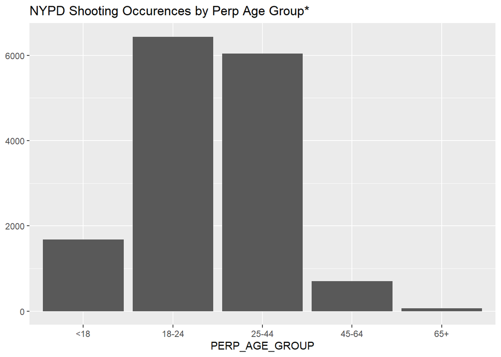

```r
  # for age factor conversion
  age_dict = setNames(seq(1,5), c("<18","18-24","25-44","45-64","65+"))
  amount_18u = length(which(nypd_data$PERP_AGE_GROUP == "<18"))
  amount_18_to_24 = length(which(nypd_data$PERP_AGE_GROUP == "18-24"))
  amount_25_to_44 = length(which(nypd_data$PERP_AGE_GROUP == "25-44"))
  amount_45_to_64 = length(which(nypd_data$PERP_AGE_GROUP == "45-64"))
  amount_65p = length(which(nypd_data$PERP_AGE_GROUP == "65+"))

  # dataframe with perp age group, occurences, and murders
  perp_age_df <- nypd_data %>%
    mutate(boro = BORO) %>%
    group_by(PERP_AGE_GROUP) %>%
    summarize(occurences = n(), murders = sum(STATISTICAL_MURDER_FLAG)) %>%
    select(PERP_AGE_GROUP, occurences, murders) %>%
    filter(PERP_AGE_GROUP %in% c("<18","18-24","25-44","45-64","65+"))

  # plots bar chart of perp age group vs occurences
  perp_age_df %>% ggplot(aes(x=PERP_AGE_GROUP, y=occurences)) +
    geom_bar(stat="identity") +
    labs(title = "NYPD Shooting Occurences by Perp Age Group*", y = NULL)
```

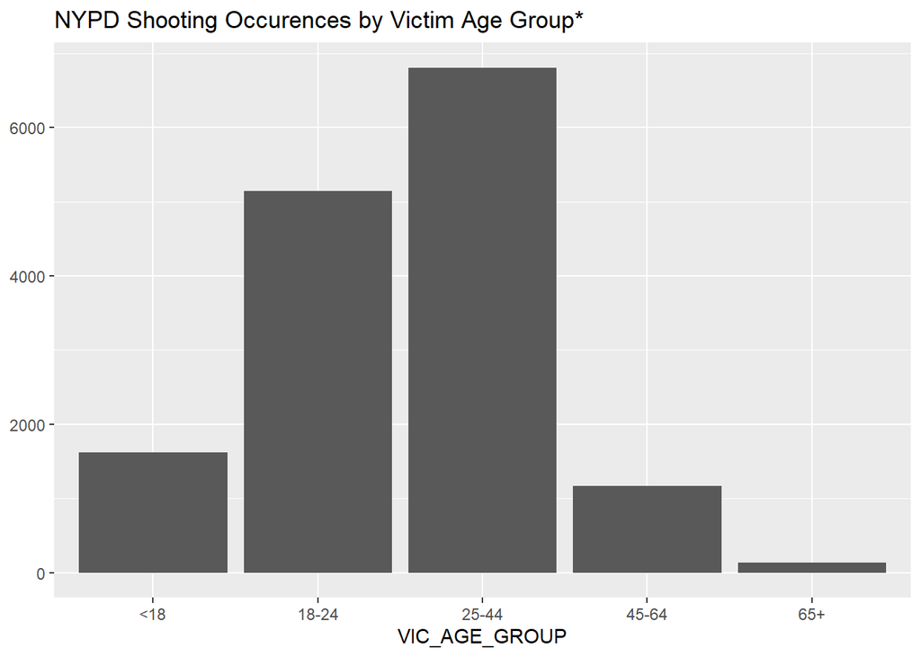

```r
  # similar to perp_age_group, but includes vic age group instead of perp
  vic_age_df <- nypd_data %>%
    filter(PERP_AGE_GROUP %in% c("<18","18-24","25-44","45-64","65+")) %>%
    filter(VIC_AGE_GROUP %in% c("<18","18-24","25-44","45-64","65+")) %>%
    mutate(boro = BORO) %>%
    group_by(VIC_AGE_GROUP) %>%
    summarize(occurences = n(), murders = sum(STATISTICAL_MURDER_FLAG)) %>%
    select(VIC_AGE_GROUP, occurences, murders)

  vic_age_df %>% ggplot(aes(x=VIC_AGE_GROUP, y=occurences)) +
    geom_bar(stat="identity") +
    labs(title = "NYPD Shooting Occurences by Victim Age Group*", y = NULL)
```

### Shooting Occurences by Perpetrator Age Group

This chart shows that the vast majority of shooting incidents [where the perp and victims’ ages are reported] are perpetrated by individuals from the ages of 18-44. This makes sense this is the majority of active adults, and also the largest population by far.

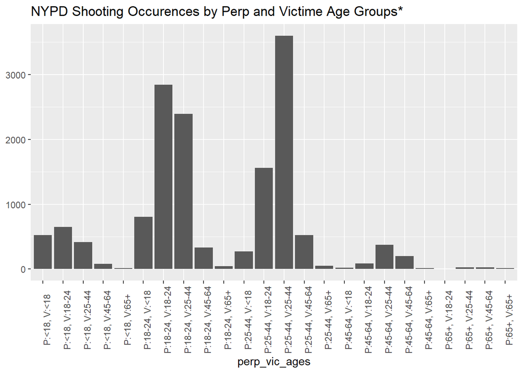

```r
  # dataframe similar to perp_age_df, but adds column combining perp age group and vic age group into a concatenated string of form P:[Perp_age_group], V:[Vic_age_group]
  perp_vic_age_df <- nypd_data %>%
    filter(PERP_AGE_GROUP %in% c("<18","18-24","25-44","45-64","65+")) %>%
    filter(VIC_AGE_GROUP %in% c("<18","18-24","25-44","45-64","65+")) %>%
    mutate(boro = BORO, perp_vic_ages = str_c("P:",PERP_AGE_GROUP, ", V:", VIC_AGE_GROUP)) %>%
    group_by(perp_vic_ages) %>%
    summarize(occurences = n(), murders = sum(STATISTICAL_MURDER_FLAG)) %>%
    select(perp_vic_ages, occurences, murders)

  # plots how many shootings there are for each perp age group on each vic age group
  perp_vic_age_df %>% ggplot(aes(x=perp_vic_ages, y=occurences)) +
    geom_bar(stat="identity") +
    theme(legend.position="bottom", axis.text.x=element_text(angle=90)) +
    labs(title = "NYPD Shooting Occurences by Perp and Victime Age Groups*", y = NULL)
```

[figure not shown]

```r
  # similar to perp_age_group, but includes vic age group instead of perp
  vic_age_df <- nypd_data %>%
    filter(PERP_AGE_GROUP %in% c("<18","18-24","25-44","45-64","65+")) %>%
    filter(VIC_AGE_GROUP %in% c("<18","18-24","25-44","45-64","65+")) %>%
    mutate(boro = BORO) %>%
    group_by(VIC_AGE_GROUP) %>%
    summarize(occurences = n(), murders = sum(STATISTICAL_MURDER_FLAG)) %>%
    select(VIC_AGE_GROUP, occurences, murders)

  # adds age_group column to vic_age_df so it can join with perp_age_df on age group
  vic_age_df_join <- vic_age_df %>%
    mutate(vic_occurences = occurences, vic_murders = murders, age_group = VIC_AGE_GROUP) %>%
    select(age_group, vic_occurences, vic_murders)

  # adds age_group column to perp_age_df so it can join with vic_age_df on age group
  perp_age_df_join <- perp_age_df %>%
    mutate(perp_occurences = occurences, perp_murders = murders, age_group = PERP_AGE_GROUP) %>%
    select(age_group, perp_occurences, perp_murders)

  # gets sum of occurenes where age is known for botht the perp and victim
  occs_sum = sum(perp_age_df$occurences)
  # same as above but for murders
  mur_sum = sum(perp_age_df$murders)

  # joins the perp_age_df and vic_age_df on age group (matches perp age group to vic age group, but both listed as age_group)
  # creates columns laying out how often each age group is the perp, how often they are the victim and what ratio they are the perp to victim and the other way around, what percent of perps they make up, what percent of victims the make up, and so on ...
  perp_vic_age_ratios_df <- perp_age_df_join %>%
    full_join(vic_age_df_join) %>%
    mutate(perp_to_vic_occs = str_c("1:", round(perp_occurences/vic_occurences,2)), perp_occ_percent = round(perp_occurences/occs_sum,3), vic_occ_percent = round(vic_occurences/occs_sum,3),perp_to_vic_murds = str_c("1:", round(perp_murders/vic_murders,2)), perp_murd_percent = round(perp_murders/mur_sum,2), vic_murd_percent = round(vic_murders/mur_sum,3), perp_over_vic_occs = round(perp_occurences/vic_occurences,2), perp_over_vic_murds = round(perp_murders/vic_murders,2)) %>%
    select(-c(perp_occurences:vic_murders))


  # shooting occurences month-to-month dataframe, similar to yearly nypd_shootings_yearly but groups by month instead of year
  nypd_shootings_monthly <- nypd_shootings_dates %>%
    mutate(month = month(OCCUR_DATE)) %>%
    group_by(month) %>%
    summarize(occurences = sum(occurences), murders = sum(murders)) %>%
    select(month, occurences)

  # function for creating x tick marks
  number_ticks <- function(n) {function(limits) pretty(limits, n)}

  # plots shooting incidents by month
  ggplot(nypd_shootings_monthly, aes(x = month, y=occurences)) +
    geom_bar(stat="identity") +
    theme(legend.position="bottom") +
    scale_x_continuous(breaks=number_ticks(10)) +
    labs(title = "NYPD Shooting Occurences by Month", y = NULL)
```

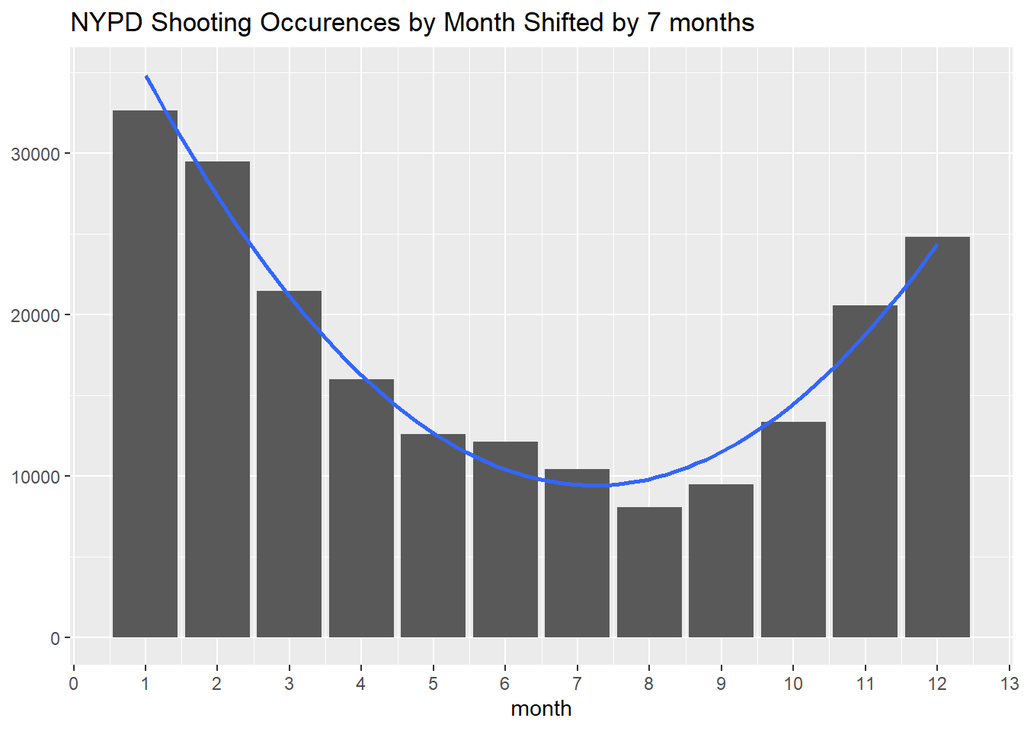

```r
  # shifts the monthly df so as to show a parabolic relationship, makes June 1, July 2, ..., May 12
  nypd_shootings_monthly_shifted <- nypd_shootings_monthly %>%
        mutate(month = ((month+ 5)%%12)+1)

  # plots the month shifted data
  ggplot(nypd_shootings_monthly_shifted, aes(x = month, y=occurences)) +
    geom_bar(stat="identity") +
    theme(legend.position="bottom") +
    scale_x_continuous(breaks=number_ticks(10)) +
    labs(title = "NYPD Shooting Occurences by Month Shifted by 7 months", y = NULL) +
    geom_smooth(se=FALSE, method = lm, formula = y ~ poly(x, 2, raw = TRUE))
```

### Shooting Occurences by Month

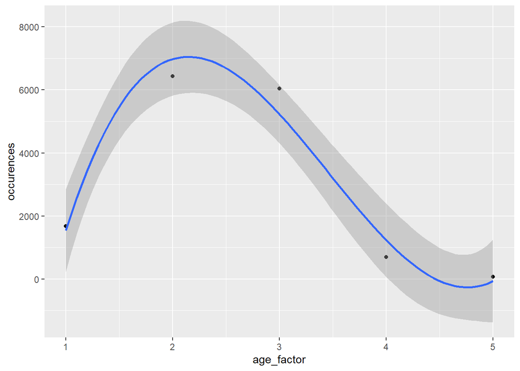

```r
  # adds age_factor column to perp_age_df, essentially ordering the age groups in numerical order
  factor_perp_df <- perp_age_df %>%
        mutate(age_factor = age_dict[PERP_AGE_GROUP])

  # creates cubic regression on the age group data between age and occurences
  mod <- lm(age_factor ~ poly(occurences, 3, raw = TRUE), data = factor_perp_df)

  # add predictions to a dataframe
  factor_perp_df_w_pred <- factor_perp_df %>% mutate(pred = predict(mod))


  # plots the age group and occurences regression
  factor_perp_df_w_pred %>% ggplot(aes(age_factor, occurences) ) + geom_point() +
  stat_smooth(method = lm, formula = y ~ poly(x, 3, raw = TRUE), level=0.55)
```

```r
  cat("*for shootings where the ages of both the victim and perpetrator were known and reported")
```

```
## *for shootings where the ages of both the victim and perpetrator were known and reported
```

### Age Group and Occurence rates Analysis

Obviously there aren’t enough age groups to really show any polynomial relationship between age groups and occurence rates, but it’s a neat visual and roughly fits a polynomial regression.

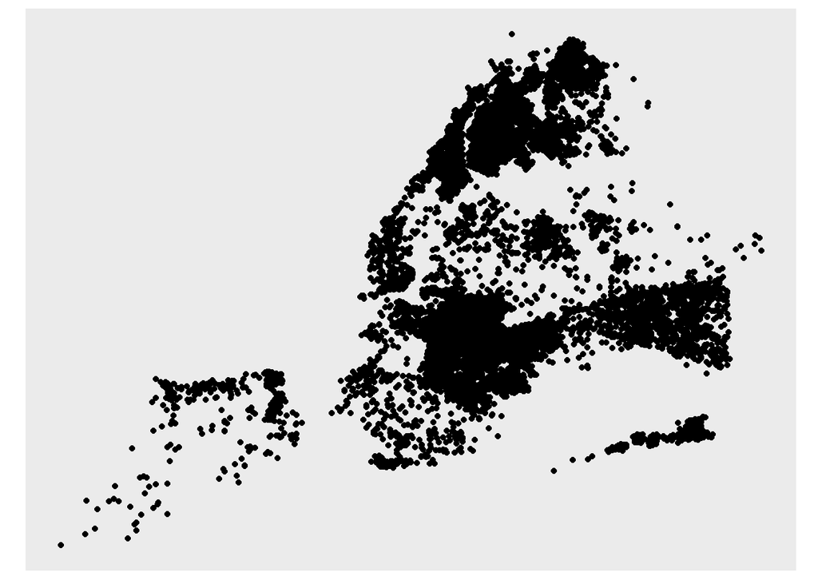

```r
nypd_locs = nypd_data_full %>%
      select(Latitude, Longitude, BORO)

nypd_locs <- na.omit(nypd_locs)


my_sf <- st_as_sf(nypd_locs, coords = c('Longitude', 'Latitude'))

# boro_dict = setNames(c("green", "red", "orange", "yellow", "purple"), c("MANHATTAN","BRONX","QUEENS","BROOKLYN","STATEN ISLAND"))
# boro_dict["MANHATTAN"]
# my_sf

ggplot(my_sf) +
  geom_sf() +
  theme(panel.grid.major = element_blank(), panel.grid.minor = element_blank(), axis.title.x=element_blank(), axis.text.x=element_blank(), axis.ticks.x=element_blank(),axis.title.y=element_blank(), axis.text.y=element_blank(), axis.ticks.y=element_blank())
```

### Dot Map Without overlay

The dots represent shooting occurences in New York City. It is somewhat hard to tell much from this graph since there isn’t a map of nyc underneath the dots (all of the map libraries I found required payment).

## Sources of Bias

- Per the NYC OpenData, Only valid shooting incidents resulting in an injured victim are included in this release. Shooting incidents not resulting in an injured victim are classified according to the appropriate offense according to NYS Penal Law
- All of my analysis on age group related data was done with data where the age group of both the perpetrator and victim where known. I didn’t do any analysis on shootings where the victim age was known and that might change the analysis.
- I don’t think there was much room for personal bias in this analysis. My way of trying to mitigate personal bias was to just just present aggregated data without trying to influence the viewer’s interpretation.